# Project Description

## Background and Context

Twitter possesses 330 million monthly active users, which allows businesses to reach a broad population and connect with customers without intermediaries. On the other hand, there’s so much information that it’s difficult for brands to quickly detect negative social mentions that could harm their business.

That's why sentiment analysis/classification, which involves monitoring emotions in conversations on social media platforms, has become a key strategy in social media marketing.

Listening to how customers feel about the product/service on Twitter allows companies to understand their audience, keep on top of what’s being said about their brand and their competitors, and discover new trends in the industry.

## Objective

To implement the techniques learned as a part of the course.

## Data Description

A sentiment analysis job about the problems of each major U.S. airline. Twitter data was scraped from February of 2015 and contributors were asked to first classify positive, negative, and neutral tweets, followed by categorizing negative reasons (such as "late flight" or "rude service").

### Data Dictionary

The dataset has the following columns:

- tweet_id
- airline_sentiment
- airline_sentiment_confidence
- negativereason
- negativereason_confidence
- airline
- airline_sentiment_gold
- name
- negativereason_gold
- retweet_count
- text
- tweet_coord
- tweet_created
- tweet_location
- user_timezone

# Load Dataset and Summary

## Importing Libraries

```python
# install and import necessary libraries.

#!pip install contractions

import re, string, unicodedata                          # Import Regex, string and unicodedata.
import contractions                                     # Import contractions library.
from bs4 import BeautifulSoup                           # Import BeautifulSoup.

import numpy as np                                      # Import numpy.
import pandas as pd                                     # Import pandas.
import nltk                                             # Import Natural Language Tool-Kit.

nltk.download('stopwords')                              # Download Stopwords.
nltk.download('punkt')
nltk.download('wordnet')

from google.colab import drive                          # Import Drive

from nltk.corpus import stopwords                       # Import stopwords.
from nltk.tokenize import word_tokenize, sent_tokenize  # Import Tokenizer.
from nltk.stem.wordnet import WordNetLemmatizer         # Import Lemmatizer.
import matplotlib.pyplot as plt                         # Import plt for visualization
import seaborn as sns                                   # Import plt for visualization

import wordcloud                                        # Import Wordcloud

import warnings
warnings.filterwarnings("ignore")
```

## Loading the Data

```python
data_path = '/content/drive/MyDrive/Colab Notebooks/data/twitter_sentiments/'
drive.mount('/content/drive')
data = pd.read_csv(data_path + 'Tweets.csv')
```

## Data Description

```python
data.head()
```

|  | tweet_id | airline_sentiment | airline_sentiment_confidence | negativereason | negativereason_confidence | airline | airline_sentiment_gold | name | negativereason_gold | retweet_count | text | tweet_coord | tweet_created | tweet_location | user_timezone |
| --- | --- | --- | --- | --- | --- | --- | --- | --- | --- | --- | --- | --- | --- | --- | --- |
| 0 | 570306133677760513 | neutral | 1.0000 | NaN | NaN | Virgin America | NaN | cairdin | NaN | 0 | @VirginAmerica What @dhepburn said. | NaN | 2015-02-24 11:35:52 -0800 | NaN | Eastern Time (US & Canada) |
| 1 | 570301130888122368 | positive | 0.3486 | NaN | 0.0000 | Virgin America | NaN | jnardino | NaN | 0 | @VirginAmerica plus you've added commercials t... | NaN | 2015-02-24 11:15:59 -0800 | NaN | Pacific Time (US & Canada) |
| 2 | 570301083672813571 | neutral | 0.6837 | NaN | NaN | Virgin America | NaN | yvonnalynn | NaN | 0 | @VirginAmerica I didn't today... Must mean I n... | NaN | 2015-02-24 11:15:48 -0800 | Lets Play | Central Time (US & Canada) |
| 3 | 570301031407624196 | negative | 1.0000 | Bad Flight | 0.7033 | Virgin America | NaN | jnardino | NaN | 0 | @VirginAmerica it's really aggressive to blast... | NaN | 2015-02-24 11:15:36 -0800 | NaN | Pacific Time (US & Canada) |
| 4 | 570300817074462722 | negative | 1.0000 | Can't Tell | 1.0000 | Virgin America | NaN | jnardino | NaN | 0 | @VirginAmerica and it's a really big bad thing... | NaN | 2015-02-24 11:14:45 -0800 | NaN | Pacific Time (US & Canada) |

```python
print(data.shape)
```

```
(14640, 15)
```

- There are 14,640 tweets in the dataset

```python
data.info()
```

```
<class 'pandas.core.frame.DataFrame'>
RangeIndex: 14640 entries, 0 to 14639
Data columns (total 15 columns):
 #   Column                        Non-Null Count  Dtype
---  ------                        --------------  -----
 0   tweet_id                      14640 non-null  int64
 1   airline_sentiment             14640 non-null  object
 2   airline_sentiment_confidence  14640 non-null  float64
 3   negativereason                9178 non-null   object
 4   negativereason_confidence     10522 non-null  float64
 5   airline                       14640 non-null  object
 6   airline_sentiment_gold        40 non-null     object
 7   name                          14640 non-null  object
 8   negativereason_gold           32 non-null     object
 9   retweet_count                 14640 non-null  int64
 10  text                          14640 non-null  object
 11  tweet_coord                   1019 non-null   object
 12  tweet_created                 14640 non-null  object
 13  tweet_location                9907 non-null   object
 14  user_timezone                 9820 non-null   object
dtypes: float64(2), int64(2), object(11)
memory usage: 1.7+ MB
```

## Data Description

The below function, will give these output in Dataframe

- Zero Values
- Missing Values
- % of Total Values
- Total Zero Missing Values
- % Total Zero Missing Values
- Data Type

```python
def missing_zero_values_table(df):
        zero_val = (df == 0.00).astype(int).sum(axis=0)                                            # Nu of zero in each column
        mis_val = df.isnull().sum()                                                                #Missing value in each column
        mis_val_percent = 100 * df.isnull().sum() / len(df)                                        #Missing value percent accross column
        mz_table = pd.concat([zero_val, mis_val, mis_val_percent], axis=1)                         #Concatenation of above aoutput
        mz_table = mz_table.rename(
        columns = {0 : 'Zero Values', 1 : 'Missing Values', 2 : '% of Total Values'})               #Renaming of each coumn
        mz_table['Total Zero Missing Values'] = mz_table['Zero Values'] + mz_table['Missing Values']  #column having total of zero value and missing values
        mz_table['% Total Zero Missing Values'] = 100 * mz_table['Total Zero Missing Values'] / len(df) # Column having percentage of totalof zero and missing value
        mz_table['Data Type'] = df.dtypes
        mz_table = mz_table[
            mz_table.iloc[:,1] != 0].sort_values(                                                     #Selecting and sorting those column which have at not a zero value in % of Total Values column
        '% of Total Values', ascending=False).round(1)
        print ("Your selected dataframe has " + str(df.shape[1]) + " columns and " + str(df.shape[0]) + " Rows.\n"
            "There are " + str(mz_table.shape[0]) +
              " columns that have missing values.")
#         mz_table.to_excel('D:/sampledata/missing_and_zero_values.xlsx', freeze_panes=(1,0), index = False)
        return mz_table

missing_zero_values_table(data)
```

```
Your selected dataframe has 15 columns and 14640 Rows.
There are 7 columns that have missing values.
```

|  | Zero Values | Missing Values | % of Total Values | Total Zero Missing Values | % Total Zero Missing Values | Data Type |
| --- | --- | --- | --- | --- | --- | --- |
| negativereason_gold | 0 | 14608 | 99.8 | 14608 | 99.8 | object |
| airline_sentiment_gold | 0 | 14600 | 99.7 | 14600 | 99.7 | object |
| tweet_coord | 0 | 13621 | 93.0 | 13621 | 93.0 | object |
| negativereason | 0 | 5462 | 37.3 | 5462 | 37.3 | object |
| user_timezone | 0 | 4820 | 32.9 | 4820 | 32.9 | object |
| tweet_location | 0 | 4733 | 32.3 | 4733 | 32.3 | object |
| negativereason_confidence | 1344 | 4118 | 28.1 | 5462 | 37.3 | float64 |

```python
data.shape
```

```
(14640, 15)
```

```python
pd.set_option('display.max_colwidth', None) # Display full dataframe information (Non-turncated Text column.)

data.head()
```

|  | tweet_id | airline_sentiment | airline_sentiment_confidence | negativereason | negativereason_confidence | airline | airline_sentiment_gold | name | negativereason_gold | retweet_count | text | tweet_coord | tweet_created | tweet_location | user_timezone |
| --- | --- | --- | --- | --- | --- | --- | --- | --- | --- | --- | --- | --- | --- | --- | --- |
| 0 | 570306133677760513 | neutral | 1.0000 | NaN | NaN | Virgin America | NaN | cairdin | NaN | 0 | @VirginAmerica What @dhepburn said. | NaN | 2015-02-24 11:35:52 -0800 | NaN | Eastern Time (US & Canada) |
| 1 | 570301130888122368 | positive | 0.3486 | NaN | 0.0000 | Virgin America | NaN | jnardino | NaN | 0 | @VirginAmerica plus you've added commercials to the experience... tacky. | NaN | 2015-02-24 11:15:59 -0800 | NaN | Pacific Time (US & Canada) |
| 2 | 570301083672813571 | neutral | 0.6837 | NaN | NaN | Virgin America | NaN | yvonnalynn | NaN | 0 | @VirginAmerica I didn't today... Must mean I need to take another trip! | NaN | 2015-02-24 11:15:48 -0800 | Lets Play | Central Time (US & Canada) |
| 3 | 570301031407624196 | negative | 1.0000 | Bad Flight | 0.7033 | Virgin America | NaN | jnardino | NaN | 0 | @VirginAmerica it's really aggressive to blast obnoxious "entertainment" in your guests' faces &amp; they have little recourse | NaN | 2015-02-24 11:15:36 -0800 | NaN | Pacific Time (US & Canada) |
| 4 | 570300817074462722 | negative | 1.0000 | Can't Tell | 1.0000 | Virgin America | NaN | jnardino | NaN | 0 | @VirginAmerica and it's a really big bad thing about it | NaN | 2015-02-24 11:14:45 -0800 | NaN | Pacific Time (US & Canada) |

# Exploratory data analysis (EDA)

1. Plot the distribution of all tweets among each airline & plot the distribution of sentiment across all the tweets.
2. Plot the distribution of Sentiment of tweets for each airline & plot the distribution of all the negative reasons.
3. Plot the word cloud graph of tweets for positive and negative sentiment separately.

## Definition of Functions

```python
# function to create labeled barplots


def labeled_barplot(data, feature, perc=False, n=None):
    """
    Barplot with percentage at the top

    data: dataframe
    feature: dataframe column
    perc: whether to display percentages instead of count (default is False)
    n: displays the top n category levels (default is None, i.e., display all levels)
    """

    total = len(data[feature])  # length of the column
    count = data[feature].nunique()
    if n is None:
        plt.figure(figsize=(count + 1, 5))
    else:
        plt.figure(figsize=(n + 1, 5))

    plt.xticks(rotation=90, fontsize=15)
    ax = sns.countplot(
        data=data,
        x=feature,
        palette="Paired",
        order=data[feature].value_counts().index[:n].sort_values(),
    )

    for p in ax.patches:
        if perc == True:
            label = "{:.1f}%".format(
                100 * p.get_height() / total
            )  # percentage of each class of the category
        else:
            label = p.get_height()  # count of each level of the category

        x = p.get_x() + p.get_width() / 2  # width of the plot
        y = p.get_height()  # height of the plot

        ax.annotate(
            label,
            (x, y),
            ha="center",
            va="center",
            size=12,
            xytext=(0, 5),
            textcoords="offset points",
        )  # annotate the percentage

    plt.show()  # show the plot


# function to plot stacked bar chart


def stacked_barplot(data, predictor, target):
    """
    Print the category counts and plot a stacked bar chart

    data: dataframe
    predictor: independent variable
    target: target variable
    """
    count = data[predictor].nunique()
    sorter = data[target].value_counts().index[-1]
    tab1 = pd.crosstab(data[predictor], data[target], margins=True).sort_values(
        by=sorter, ascending=False
    ) #.reindex([0, 1, "All"], axis=1)
    print(tab1)
    print("-" * 120)
    tab = pd.crosstab(data[predictor], data[target], normalize="index").sort_values(
        by=sorter, ascending=False
    ) #.reindex([0, 1, "All"], axis=1)
    tab.plot(kind="bar", stacked=True, figsize=(count + 1, 5))
    plt.legend(
        loc="lower left",
        frameon=False,
    )
    plt.legend(loc="upper left", bbox_to_anchor=(1, 1))
    plt.show()


# Function to Create Wordcloud
def show_wordcloud(data, variable, title):
    # data[variable] = data.apply(lambda row: nltk.word_tokenize(row[variable])
    #                               , axis=1)
    text = ' '.join(data[variable].astype(str).tolist())                 # Converting Summary column into list
    stopwords = set(wordcloud.STOPWORDS)                                  # instantiate the stopwords from wordcloud

    fig_wordcloud = wordcloud.WordCloud(stopwords=stopwords,background_color='white',          # Setting the different parameter of stopwords
                    colormap='viridis', width=800, height=600).generate(text)

    plt.figure(figsize=(14,11), frameon=True)
    plt.imshow(fig_wordcloud)
    plt.axis('off')
    plt.title(title, fontsize=30)
    plt.show()
```

## Tweet and Sentiments Distribution (Before Text Processing)

### Tweets Distribution

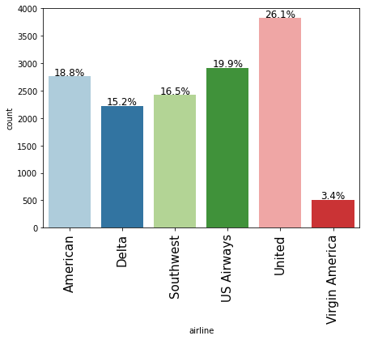

```python
labeled_barplot(data, 'airline', perc=True)
```

- Most tweets are associated with United Airline at 26.1%
- Least amount of Tweets are associated wth Virgin America at 3.4%

### Sentiments Distribution

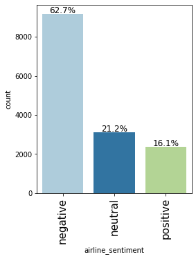

```python
labeled_barplot(data, 'airline_sentiment', perc=True)
```

- Most of the sentiments provided are negative
- Positive sentiments received are the fewest

## Sentiments and Reason Distribution (Before Text Processing)

### Airline vs Sentiment Distribution

```
airline_sentiment  negative  neutral  positive    All
airline
All                    9178     3099      2363  14640
Southwest              1186      664       570   2420
Delta                   955      723       544   2222
United                 2633      697       492   3822
American               1960      463       336   2759
US Airways             2263      381       269   2913
Virgin America          181      171       152    504
------------------------------------------------------------------------------------------------------------------------
```

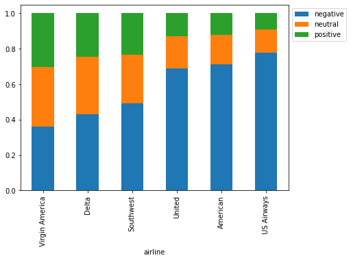

```python
stacked_barplot(data, "airline", "airline_sentiment")
```

- USAirways had the highest proportion of negative comments and least positive comments
- Virgin America had the least proportion of negative comments and highest positive comments
- As expected, the proportion of negative comments varies inversely as that of positive comments.

### Negative Reasons Distribution

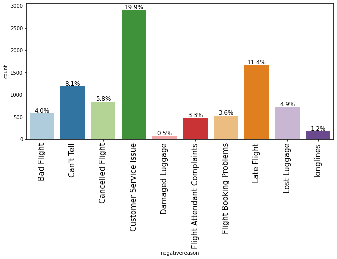

```python
labeled_barplot(data, 'negativereason', perc=True)
```

- Most negative sentiments were caused by poor customer service issue
- 8.1% of remarks cannot identify the reason behind their negative sentiment
- Very few negative remarks were motivated by damaged luggages

## Word Cloud

### Positive Sentiments

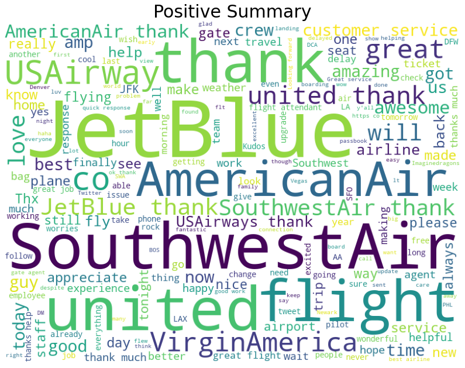

```python
show_wordcloud(data[data.airline_sentiment == 'positive'], 'text', 'Positive Summary')
```

- Airline handles like JetBlue, SouthWestAir, AmericanAir are well featured in the positive comments
- Words like great, nice, good which are prominent show verify that the tweets were well classified as positive

### Negative Sentiments

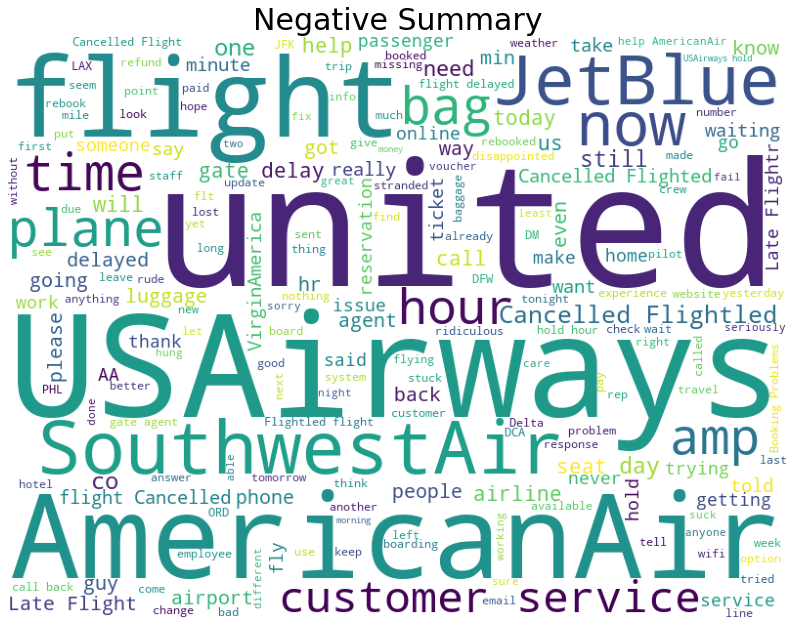

```python
show_wordcloud(data[data.airline_sentiment == 'negative'], 'text', 'Negative Summary')
```

- Airline handles like USAirways, AmericanAir, United are well featured in the negative comments
- Words like cancelled, delay, and ridiculous which feature verify that the tweets were well classified as negative

# Understanding of Data Columns

## Dropping unwanted columns

```python
data_filter = data[['text', 'airline_sentiment']].copy()
```

## New Shape

```python
data_filter.shape # Checking chape of filtered dataframe
```

```
(14640, 2)
```

## First 5 Rows

```python
data_filter.head()
```

|  | text | airline_sentiment |
| --- | --- | --- |
| 0 | @VirginAmerica What @dhepburn said. | neutral |
| 1 | @VirginAmerica plus you've added commercials to the experience... tacky. | positive |
| 2 | @VirginAmerica I didn't today... Must mean I need to take another trip! | neutral |
| 3 | @VirginAmerica it's really aggressive to blast obnoxious "entertainment" in your guests' faces &amp; they have little recourse | negative |
| 4 | @VirginAmerica and it's a really big bad thing about it | negative |

# Data Pre - Processing

This includes

- Html tag removal.
- Tokenization.
- Remove the numbers.
- Removal of Special Characters and Punctuations.
- Removal of stopwords
- Conversion to lowercase.
- Lemmatize or stemming.
- Join the words in the list to convert back to text string in the data frame. (So that each row contains the data in text format.)
- Print the first 5 rows of data after pre-processing.

**Definition of terms**

- Misplaced Characters: These are characters that were wrongly encoded in the process of data storage and extraction. e.g.
  - â€œ = left quote = “
  - â€ = right quote = ”
- Stopwords: These are commonly occuring words that does not impact the performance of our model

## Html Tag Removal

```python
# Removal of the http link using Regular Expression.
for i, row in data_filter.iterrows():
    clean_tweet = re.sub(r"http\S+", "", data_filter.at[i, 'text'])
    data_filter.at[i,'text'] = clean_tweet
data_filter.head(5)
```

|  | text | airline_sentiment |
| --- | --- | --- |
| 0 | @VirginAmerica What @dhepburn said. | neutral |
| 1 | @VirginAmerica plus you've added commercials to the experience... tacky. | positive |
| 2 | @VirginAmerica I didn't today... Must mean I need to take another trip! | neutral |
| 3 | @VirginAmerica it's really aggressive to blast obnoxious "entertainment" in your guests' faces &amp; they have little recourse | negative |
| 4 | @VirginAmerica and it's a really big bad thing about it | negative |

```python
# Misplaced Characters mapped to Corrected Character
mis_char = {'â€œ': '"',
            'â€': '"',
            'â€˜': "'",
            'â€™': "'",
            'â€”': "–",
            'â€“': "—",
            'â€¢': "-",
            'â€¦': "…",
            "&amp": "&"
           }
```

```python
# Replacement of Misplaced Characters with Corrected Characters
def remove_mis_char(words):
  for key, value in mis_char.items():
    words.replace(key, value)
  return words

data_filter['text'] = data_filter['text'].apply(remove_mis_char)
data_filter.head(5)
```

|  | text | airline_sentiment |
| --- | --- | --- |
| 0 | @VirginAmerica What @dhepburn said. | neutral |
| 1 | @VirginAmerica plus you've added commercials to the experience... tacky. | positive |
| 2 | @VirginAmerica I didn't today... Must mean I need to take another trip! | neutral |
| 3 | @VirginAmerica it's really aggressive to blast obnoxious "entertainment" in your guests' faces &amp; they have little recourse | negative |
| 4 | @VirginAmerica and it's a really big bad thing about it | negative |

## Removal of Numbers

```python
def remove_numbers(text):
  text = re.sub(r'\d+', '', text)
  return text

data_filter['text'] = data_filter['text'].apply(lambda x: remove_numbers(x))
data_filter.head(5)
```

|  | text | airline_sentiment |
| --- | --- | --- |
| 0 | @VirginAmerica What @dhepburn said. | neutral |
| 1 | @VirginAmerica plus you've added commercials to the experience... tacky. | positive |
| 2 | @VirginAmerica I didn't today... Must mean I need to take another trip! | neutral |
| 3 | @VirginAmerica it's really aggressive to blast obnoxious "entertainment" in your guests' faces &amp; they have little recourse | negative |
| 4 | @VirginAmerica and it's a really big bad thing about it | negative |

## Replace Contractions

```python
def replace_contractions(text):
    """Replace contractions in string of text"""
    return contractions.fix(text)

data_filter['text'] = data_filter['text'].apply(lambda x: replace_contractions(x))
data_filter.head()
```

|  | text | airline_sentiment |
| --- | --- | --- |
| 0 | @VirginAmerica What @dhepburn said. | neutral |
| 1 | @VirginAmerica plus you have added commercials to the experience... tacky. | positive |
| 2 | @VirginAmerica I did not today... Must mean I need to take another trip! | neutral |
| 3 | @VirginAmerica it is really aggressive to blast obnoxious "entertainment" in your guests' faces &amp; they have little recourse | negative |
| 4 | @VirginAmerica and it is a really big bad thing about it | negative |

## Tokenization

```python
data_filter['text'] = data_filter.apply(lambda row: nltk.word_tokenize(row['text']), axis=1) # Tokenization of data
data_filter.head()
```

|  | text | airline_sentiment |
| --- | --- | --- |
| 0 | [@, VirginAmerica, What, @, dhepburn, said, .] | neutral |
| 1 | [@, VirginAmerica, plus, you, have, added, commercials, to, the, experience, ..., tacky, .] | positive |
| 2 | [@, VirginAmerica, I, did, not, today, ..., Must, mean, I, need, to, take, another, trip, !] | neutral |
| 3 | [@, VirginAmerica, it, is, really, aggressive, to, blast, obnoxious, ``, entertainment, '', in, your, guests, ', faces, &, amp, ;, they, have, little, recourse] | negative |
| 4 | [@, VirginAmerica, and, it, is, a, really, big, bad, thing, about, it] | negative |

## Remove of non-ascii Characters

```python
def remove_non_ascii(words):
    """Remove non-ASCII characters from list of tokenized words"""
    new_words = []                        # Create empty list to store pre-processed words.
    for word in words:
        new_word = unicodedata.normalize('NFKD', word).encode('ascii', 'ignore').decode('utf-8', 'ignore')
        new_words.append(new_word)        # Append processed words to new list.
    return new_words


data_filter['text'] = data_filter['text'].apply(lambda x: remove_non_ascii(x))
data_filter.head()
```

|  | text | airline_sentiment |
| --- | --- | --- |
| 0 | [@, VirginAmerica, What, @, dhepburn, said, .] | neutral |
| 1 | [@, VirginAmerica, plus, you, have, added, commercials, to, the, experience, ..., tacky, .] | positive |
| 2 | [@, VirginAmerica, I, did, not, today, ..., Must, mean, I, need, to, take, another, trip, !] | neutral |
| 3 | [@, VirginAmerica, it, is, really, aggressive, to, blast, obnoxious, ``, entertainment, '', in, your, guests, ', faces, &, amp, ;, they, have, little, recourse] | negative |
| 4 | [@, VirginAmerica, and, it, is, a, really, big, bad, thing, about, it] | negative |

## Remove of Special Characters and Punctuation

```python
def remove_punctuation(words):
    """Remove punctuation from list of tokenized words"""
    new_words = []                        # Create empty list to store pre-processed words.
    for word in words:
        new_word = re.sub(r'[^\w\s]', '', word)
        if new_word != '':
            new_words.append(new_word)    # Append processed words to new list.
    return new_words

data_filter['text'] = data_filter['text'].apply(lambda x: remove_punctuation(x))
data_filter.head()
```

|  | text | airline_sentiment |
| --- | --- | --- |
| 0 | [VirginAmerica, What, dhepburn, said] | neutral |
| 1 | [VirginAmerica, plus, you, have, added, commercials, to, the, experience, tacky] | positive |
| 2 | [VirginAmerica, I, did, not, today, Must, mean, I, need, to, take, another, trip] | neutral |
| 3 | [VirginAmerica, it, is, really, aggressive, to, blast, obnoxious, entertainment, in, your, guests, faces, amp, they, have, little, recourse] | negative |
| 4 | [VirginAmerica, and, it, is, a, really, big, bad, thing, about, it] | negative |

## Lowercasing all Characters

```python
def to_lowercase(words):
    """Convert all characters to lowercase from list of tokenized words"""
    new_words = []
    for word in words:
        new_word = word.lower()
        new_words.append(new_word)
    return new_words

data_filter['text'] = data_filter['text'].apply(lambda x: to_lowercase(x))
data_filter.head()
```

|  | text | airline_sentiment |
| --- | --- | --- |
| 0 | [virginamerica, what, dhepburn, said] | neutral |
| 1 | [virginamerica, plus, you, have, added, commercials, to, the, experience, tacky] | positive |
| 2 | [virginamerica, i, did, not, today, must, mean, i, need, to, take, another, trip] | neutral |
| 3 | [virginamerica, it, is, really, aggressive, to, blast, obnoxious, entertainment, in, your, guests, faces, amp, they, have, little, recourse] | negative |
| 4 | [virginamerica, and, it, is, a, really, big, bad, thing, about, it] | negative |

## Removal of Stop Words

```python
# Excluded Stop words
stopwords = stopwords.words('english')

customlist = ['not', "couldn't", 'didn', "didn't", 'doesn', "doesn't", 'hadn', "hadn't", 'hasn',
        "hasn't", 'haven', "haven't", 'isn', "isn't", 'ma', 'mightn', "mightn't", 'mustn',
        "mustn't", 'needn', "needn't", 'shan', "shan't", 'shouldn', "shouldn't", 'wasn',
        "wasn't", 'weren', "weren't", 'won', "won't", 'wouldn', "wouldn't"]

# Set custom stop-word's list as not, couldn't etc. words matter in Sentiment, so not removing them from original data.

stopwords = list(set(stopwords) - set(customlist))
```

```python
def remove_stopwords(words):
    """Remove stop words from list of tokenized words"""
    new_words = []
    for word in words:
        if word not in stopwords:
            new_words.append(word)
    return new_words

data_filter['text'] = data_filter['text'].apply(lambda x: remove_stopwords(x))
data_filter.head()
```

|  | text | airline_sentiment |
| --- | --- | --- |
| 0 | [virginamerica, dhepburn, said] | neutral |
| 1 | [virginamerica, plus, added, commercials, experience, tacky] | positive |
| 2 | [virginamerica, not, today, must, mean, need, take, another, trip] | neutral |
| 3 | [virginamerica, really, aggressive, blast, obnoxious, entertainment, guests, faces, amp, little, recourse] | negative |
| 4 | [virginamerica, really, big, bad, thing] | negative |

## Lemmatization

```python
def lemmatize_list(words):
    lemmatizer = WordNetLemmatizer()
    new_words = []
    for word in words:
      new_words.append(lemmatizer.lemmatize(word, pos='v'))
    return new_words

data_filter['text'] = data_filter['text'].apply(lambda x: lemmatize_list(x))
data_filter.head()
```

|  | text | airline_sentiment |
| --- | --- | --- |
| 0 | [virginamerica, dhepburn, say] | neutral |
| 1 | [virginamerica, plus, add, commercials, experience, tacky] | positive |
| 2 | [virginamerica, not, today, must, mean, need, take, another, trip] | neutral |
| 3 | [virginamerica, really, aggressive, blast, obnoxious, entertainment, guests, face, amp, little, recourse] | negative |
| 4 | [virginamerica, really, big, bad, thing] | negative |

## Token to Sentence

```python
data_filter['text'] = data_filter['text'].apply(lambda x: ' '.join(x)) # Tokenization of data
data_filter.head()
```

|  | text | airline_sentiment |
| --- | --- | --- |
| 0 | virginamerica dhepburn say | neutral |
| 1 | virginamerica plus add commercials experience tacky | positive |
| 2 | virginamerica not today must mean need take another trip | neutral |
| 3 | virginamerica really aggressive blast obnoxious entertainment guests face amp little recourse | negative |
| 4 | virginamerica really big bad thing | negative |

## Word Cloud (After Text Processing)

### Positive Sentiments

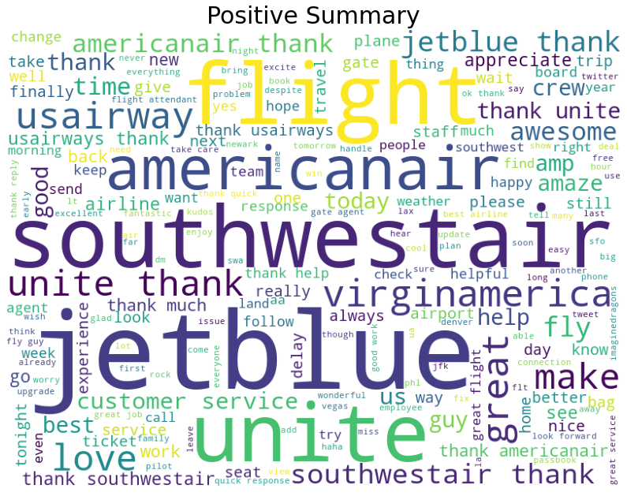

```python
show_wordcloud(data_filter[data.airline_sentiment == 'positive'], 'text', 'Positive Summary')
```

- As already seen in the EDA, virginiaamerica, Jetblue and Southwestair are common in positive comments by the customers
- Commendation words like great, appreciate, awesome, thank all featured in the word cloud as would be expected in positive comments

### Negative Sentiments

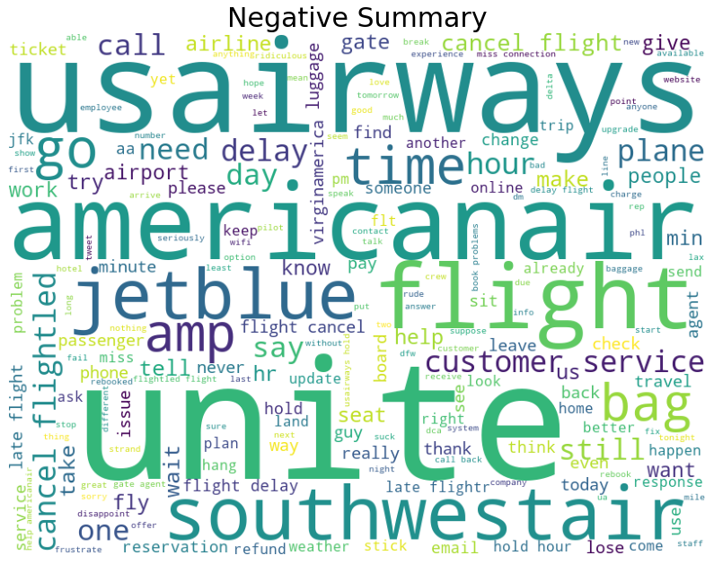

```python
show_wordcloud(data_filter[data.airline_sentiment == 'negative'], 'text', 'Negative Summary')
```

- As already seen in the EDA, US Airways, American Air and United Air are common in negative comments by the customers
- Dissaproval words words like delay. This is supported by terms relating to time like hour, day, wait.
- Customers seemed to have numerous issues with the customer service as it was featured

# Vectorization

```python
# Maximun obtainable features
len(set(nltk.word_tokenize(data_filter['text'].str.cat(sep=' '))))
```

```
10868
```

- A maximum of 10,868 text features can be extracted
- About 25% of the features will be used

## Count Vectorizer Technique

```python
# Vectorization (Convert text data to numbers).
from sklearn.feature_extraction.text import CountVectorizer

bow_vec = CountVectorizer(max_features=3000)                # Keep only 2000 features as number of features will increase the processing time.
cv_features = bow_vec.fit_transform(data_filter['text'])

cv_features = cv_features.toarray()
```

```python
# Shape of the resulting Array
print(cv_features.shape)
```

```
(14640, 3000)
```

## TFIDF Vectorizer Technique

```python
# Using TfidfVectorizer to convert text data to numbers.

from sklearn.feature_extraction.text import TfidfVectorizer

vectorizer_tf = TfidfVectorizer(max_features=3000, ngram_range=(1,2))
tfid_features = vectorizer_tf.fit_transform(data['text'])

tfid_features = tfid_features.toarray()
```

```python
# Shape of the resulting Array
print(tfid_features.shape)
```

```
(14640, 3000)
```

# Modelling , tuning and Evaluation

## Encoding of Target Variable

```python
labels = data['airline_sentiment']
# labels = labels.astype('int')
```

## Count Vectorizer

```python
# Split data into training and testing set.

from sklearn.model_selection import train_test_split

X_train, X_test, y_train, y_test = train_test_split(cv_features, labels, test_size=0.3, random_state=42, stratify = labels)
```

```python
# Using Random Forest to build model for the classification of reviews.
# Also calculating the cross validation score.

from sklearn.ensemble import RandomForestClassifier
from sklearn.model_selection import cross_val_score

forest_cv = RandomForestClassifier(n_estimators=10, n_jobs=-1)

forest_cv = forest_cv.fit(X_train, y_train)

print(forest_cv)

print(np.mean(cross_val_score(forest_cv, cv_features, labels, cv=10)))
```

```
RandomForestClassifier(n_estimators=10, n_jobs=-1)
0.7209699453551913
```

### Optimizing the parameter: Number of trees in the random forest model (n_estimators)

```python
# Finding optimal number of base learners using k-fold CV ->
base_ln = [x for x in range(1, 25)]
```

```python
# K-Fold Cross - validation .
cv_scores = []
for b in base_ln:
    clf = RandomForestClassifier(n_estimators = b)
    scores = cross_val_score(clf, X_train, y_train, cv = 5, scoring = 'accuracy')
    cv_scores.append(scores.mean())
```

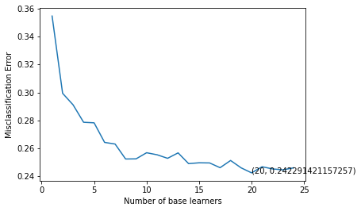

```python
# plotting the error as k increases
error = [1 - x for x in cv_scores]                                 #error corresponds to each nu of estimator
optimal_learners = base_ln[error.index(min(error))]                #Selection of optimal nu of n_estimator corresponds to minimum error.
plt.plot(base_ln, error)                                           #Plot between each nu of estimator and misclassification error
xy = (optimal_learners, min(error))
plt.annotate('(%s, %s)' % xy, xy = xy, textcoords='data')
plt.xlabel("Number of base learners")
plt.ylabel("Misclassification Error")
plt.show()
```

```python
# Training the best model and calculating accuracy on test data .
clf = RandomForestClassifier(n_estimators = optimal_learners, n_jobs=-1, random_state=42)
clf.fit(X_train, y_train)
clf.score(X_test, y_test)
```

```
0.7572859744990893
```

```python
#saving the prediction on test data as a result
result =  clf.predict(X_test)
```

```
[[2475  196   82]
 [ 386  445   99]
 [ 174  129  406]]
0.7572859744990893
```

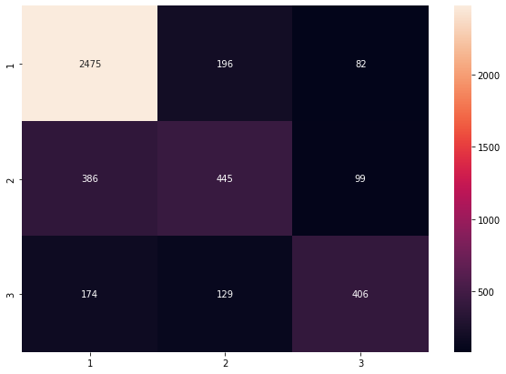

```python
# Print and plot Confusion matirx to get an idea of how the distribution of the prediction is, among all the classes.

import matplotlib.pyplot as plt
import seaborn as sns
from sklearn import metrics
from sklearn.metrics import confusion_matrix

conf_mat = confusion_matrix(y_test, result)

print(conf_mat)

print(metrics.f1_score(y_test, result,average='micro'))

df_cm = pd.DataFrame(conf_mat, index = [i for i in "123"],
                  columns = [i for i in "123"])
plt.figure(figsize = (10,7))
sns.heatmap(df_cm, annot=True, fmt='g')
```

### Word Cloud of top 40 important features from the CountVectorizer + Random Forest based model

```
Here are the top 40 words

thank not great usairways delay jetblue flight cancel unite love hold awesome bag hours get southwestair wait americanair call best hour virginamerica amaze customer help miss follow still time dm make fly please tell would good service appreciate phone try
```

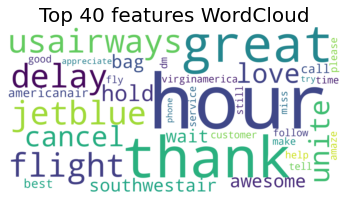

```python
all_features = bow_vec.get_feature_names()              #Instantiate the feature from the vectorizer
top_features=''                                            # Addition of top 40 feature into top_feature after training the model
feat=clf.feature_importances_
features=np.argsort(feat)[::-1]
for i in features[0:40]:
    top_features+=all_features[i]
    top_features+=' '

print('Here are the top 40 words', '\n')
print(top_features, '\n')

from wordcloud import WordCloud
wordcloud = WordCloud(background_color="white",colormap='viridis',width=2000,
                          height=1000).generate(top_features)

# Display the generated image:
plt.imshow(wordcloud, interpolation='bilinear')
plt.figure(1, figsize=(14, 11), frameon='equal')
plt.title('Top 40 features WordCloud', fontsize=20)
plt.axis("off")
plt.show()
```

## TFIDF Vectorizer

```python
# Split data into training and testing set.

from sklearn.model_selection import train_test_split

X_train, X_test, y_train, y_test = train_test_split(tfid_features, labels, test_size=0.3, random_state=42, stratify = labels)
```

```python
# Using Random Forest to build model for the classification of reviews.
# Also calculating the cross validation score.

from sklearn.ensemble import RandomForestClassifier
from sklearn.model_selection import cross_val_score

forest_tf = RandomForestClassifier(n_estimators=10, n_jobs=-1)

forest_tf = forest_tf.fit(X_train, y_train)

print(forest_tf)

print(np.mean(cross_val_score(forest_tf, cv_features, labels, cv=10)))
```

```
RandomForestClassifier(n_estimators=10, n_jobs=-1)
0.7174863387978142
```

### Optimizing the parameter: Number of trees in the random forest model (n_estimators)

```python
# Finding optimal number of base learners using k-fold CV ->
base_ln = [x for x in range(1, 25)]
```

```python
# K-Fold Cross - validation .
cv_scores = []
for b in base_ln:
    clf = RandomForestClassifier(n_estimators = b)
    scores = cross_val_score(clf, X_train, y_train, cv = 5, scoring = 'accuracy')
    cv_scores.append(scores.mean())
```

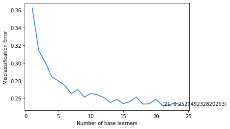

```python
# plotting the error as k increases
error = [1 - x for x in cv_scores]                                 #error corresponds to each nu of estimator
optimal_learners = base_ln[error.index(min(error))]                #Selection of optimal nu of n_estimator corresponds to minimum error.
plt.plot(base_ln, error)                                           #Plot between each nu of estimator and misclassification error
xy = (optimal_learners, min(error))
plt.annotate('(%s, %s)' % xy, xy = xy, textcoords='data')
plt.xlabel("Number of base learners")
plt.ylabel("Misclassification Error")
plt.show()
```

```python
# Training the best model and calculating accuracy on test data .
clf = RandomForestClassifier(n_estimators = optimal_learners, n_jobs=-1, random_state=42)
clf.fit(X_train, y_train)
clf.score(X_test, y_test)
```

```
0.7561475409836066
```

```python
#saving the prediction on test data as a result
result =  clf.predict(X_test)
```

```
[[2593  115   45]
 [ 490  384   56]
 [ 270   95  344]]
0.7561475409836066
```

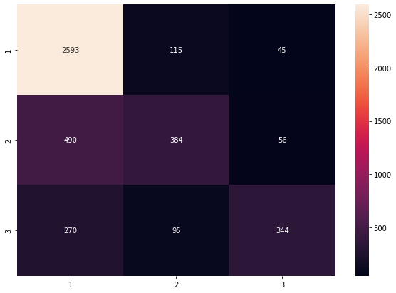

```python
# Print and plot Confusion matirx to get an idea of how the distribution of the prediction is, among all the classes.

import matplotlib.pyplot as plt
import seaborn as sns
from sklearn import metrics
from sklearn.metrics import confusion_matrix

conf_mat = confusion_matrix(y_test, result)

print(conf_mat)

print(metrics.f1_score(y_test, result,average='micro'))

df_cm = pd.DataFrame(conf_mat, index = [i for i in "123"],
                  columns = [i for i in "123"])
plt.figure(figsize = (10,7))
sns.heatmap(df_cm, annot=True, fmt='g')
```

[output not shown]

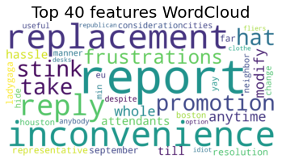

```python
all_features = bow_vec.get_feature_names()              #Instantiate the feature from the vectorizer
top_features=''                                            # Addition of top 40 feature into top_feature after training the model
feat=clf.feature_importances_
features=np.argsort(feat)[::-1]
for i in features[0:40]:
    top_features+=all_features[i]
    top_features+=' '

print('Here are the top 40 words', '\n')
print(top_features, '\n')

from wordcloud import WordCloud
wordcloud = WordCloud(background_color="white",colormap='viridis',width=2000,
                          height=1000).generate(top_features)

# Display the generated image:
plt.imshow(wordcloud, interpolation='bilinear')
plt.figure(1, figsize=(14, 11), frameon='equal')
plt.title('Top 40 features WordCloud', fontsize=20)
plt.axis("off")
plt.show()
```

# Conclusion and Recommendation

## Conclusion

- We created a Word Cloud plot based on summary and high and low score.
- The pre-processed data is converted to numbers (vectorized) using two different methods.
- We trained the model and optimized the parameter, which led to an increase the overall accuracy.
- After building the classification model, we predicted the results for the test data.
- The model performed well in perspective of how text classification models perform.
- For this Model, Count Vectorizer model performed slightly better than the TF-IDF Vectorizer Model
- We used a dataset which has extracted tweets in text format and their sentiment whether it is positive, negative or neutral.
- The goal was to build a model for text-classification.
- We pre-processed the data using various techniques and libraries.

## Recommendation

- More advanced pre-processing can improve model performance
- Training of a larger dataset for better generalization and dimensionality balance
- Increasing the maximum number of features.
- We can apply other model tuning and hyperparameter tuning techniques, as well as other pre-processing techniques to increase the overall accuracy even further.
- Using more powerful algorithm like Deep Learning to train the dataset